# PA1_template.Rmd

# Course Project 1 - Reproducible Research

## Loading and Processing Data

The following commands will:

1. Load the data
2. Process and transforms the data into a format suitable for analysis

Note that no adjustments have been made to NA values yet.

```r
data <- read.csv("activity.csv")
```

## What is mean total number of steps taken per day?

The following commands will:

1. Calculate the total number of steps taken per day by creating another table *data_per_day*

```r
data_per_day <- aggregate(data$steps, by=list(Date=data$date), FUN=sum)
data_per_day
```

```
##          Date     x
## 1  2012-10-01    NA
## 2  2012-10-02   126
## 3  2012-10-03 11352
## 4  2012-10-04 12116
## 5  2012-10-05 13294
## 6  2012-10-06 15420
## 7  2012-10-07 11015
## 8  2012-10-08    NA
## 9  2012-10-09 12811
## 10 2012-10-10  9900
## 11 2012-10-11 10304
## 12 2012-10-12 17382
## 13 2012-10-13 12426
## 14 2012-10-14 15098
```

[output cut: 47 more lines]

2. Make a histogram of the total number of steps taken each day using the new data.frame created above

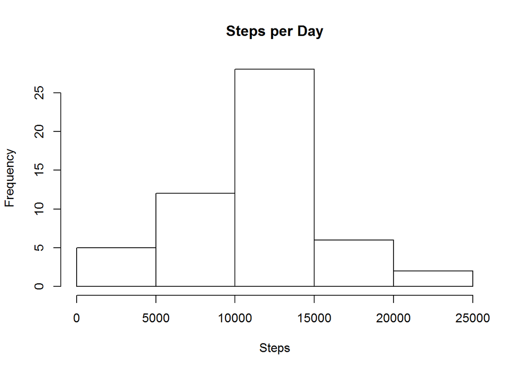

```r
hist(data_per_day$x, xlab="Steps", main="Steps per Day")
```

3. Calculate the mean and median of the total number of steps taken per day

```r
mean(data_per_day$x, na.rm=TRUE)
```

```
## [1] 10766.19
```

```r
median(data_per_day$x, na.rm=TRUE)
```

```
## [1] 10765
```

Note that no adjustments have been made to NA values yet.

## What is the average daily activity pattern?

The following commands will:

1. Make a time series plot of the 5-minute interval (x-axis) and the average number of steps taken, averaged across all days (y-axis)

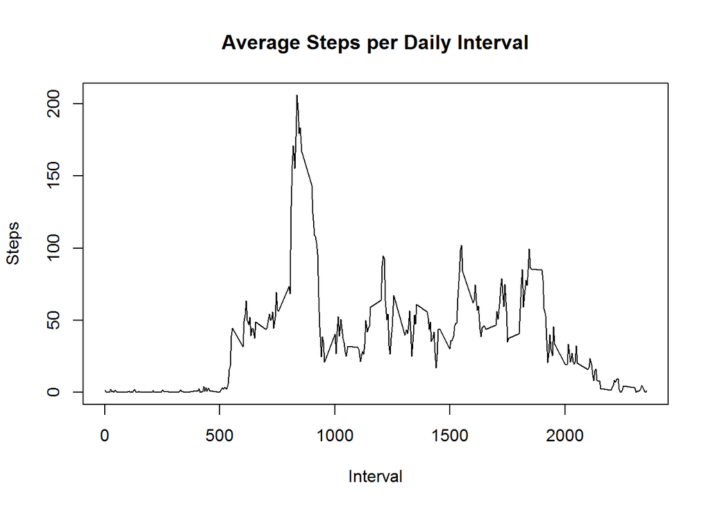

```r
data_per_interval <- aggregate(data$steps, by=list(Interval=data$interval), FUN=mean, na.rm=TRUE)
plot(data_per_interval$Interval,data_per_interval$x, type = "l", main="Average Steps per Daily Interval", xlab="Interval", ylab="Steps")
```

2. Determine which 5-minute interval, on average across all the days in the dataset, contains the maximum number of steps.

```r
data_per_interval[which.max(data_per_interval$x),]
```

```
##     Interval        x
## 104      835 206.1698
```

ie. 8:35am had the most average steps

Note that no adjustments have been made to NA values yet.

## Imputing missing values

There are a number of days/intervals where there are missing values (coded as NA). The presence of missing days may introduce bias into some calculations or summaries of the data.

The following commands will:

1. Calculate and report the total number of missing values in the dataset (i.e. the total number of rows with NAs)

```r
sum(is.na(data$steps))
```

```
## [1] 2304
```

2. In order to fill in all of the missing values in the dataset, one strategy would be to set the NAs equal to the mean for that 5-minute interval across all other days
3. Create a new dataset that is equal to the original dataset but with the missing data filled in.

```r
data2 <- merge(data, data_per_interval, by.x="interval", by.y="Interval")
is_nas <- is.na(data2$steps)
data2$steps[is_nas] <- data2$x[is_nas]
```

Check NAs:

```r
sum(is.na(data2$steps))
```

```
## [1] 0
```

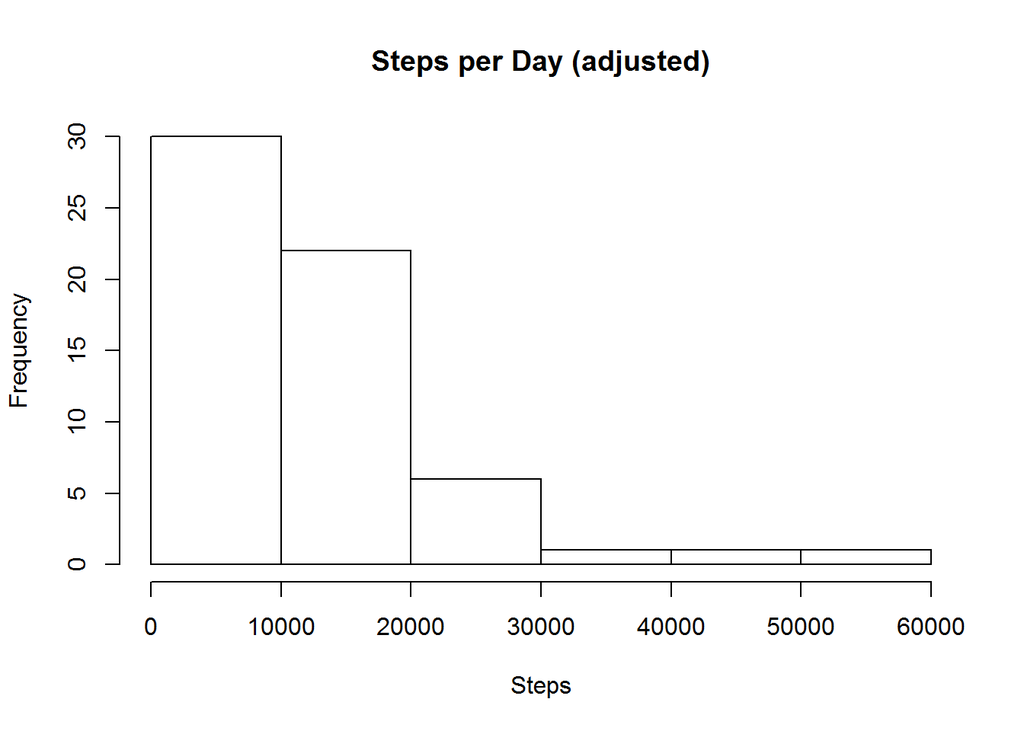

```r
data2_per_day <- aggregate(data2$steps, by=list(Date=data$date), FUN=sum)
hist(data2_per_day$x, xlab="Steps", main="Steps per Day (adjusted)")
```

```r
mean(data2_per_day$x, na.rm=TRUE)
```

```
## [1] 10766.19
```

```r
median(data2_per_day$x, na.rm=TRUE)
```

```
## [1] 10351.62
```

compared to above (without adjusting for NAs):

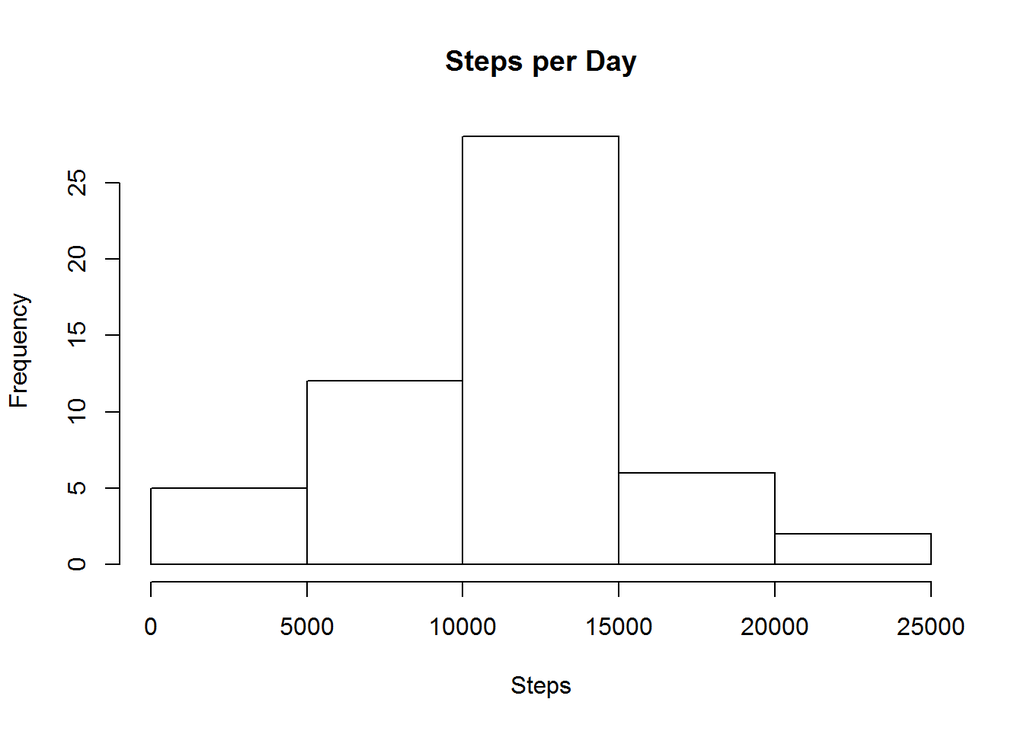

```r
hist(data_per_day$x, xlab="Steps", main="Steps per Day")
```

```r
mean(data_per_day$x, na.rm=TRUE)
```

```
## [1] 10766.19
```

```r
median(data_per_day$x, na.rm=TRUE)
```

```
## [1] 10765
```

## Are there differences in activity patterns between weekdays and weekends?

For this part the weekdays() function may be of some help here. Use the dataset with the filled-in missing values for this part.

1. Create a new factor variable in the dataset with two levels – “weekday” and “weekend” indicating whether a given date is a weekday or weekend day.

```r
data2$weekend <- ifelse(weekdays(as.POSIXct(data2$date))=="Sunday" | weekdays(as.POSIXct(data2$date))=="Saturday", "Weekend", "Weekday")
```

2. Make a panel plot containing a time series plot (i.e. type = “l”) of the 5-minute interval (x-axis) and the average number of steps taken, averaged across all weekday days or weekend days (y-axis).

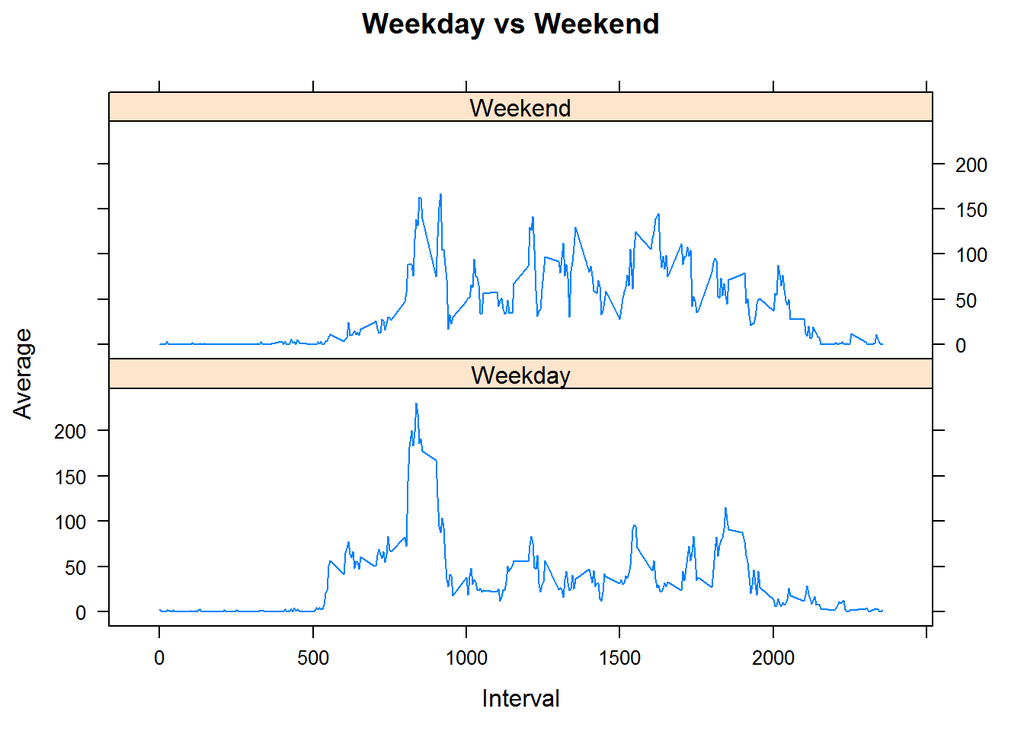

```r
data2_per_interval <- aggregate(data2$steps, by=list(Interval=data2$interval, "Weekday"=data2$weekend), FUN=mean, na.rm=TRUE)
library(lattice)
xyplot(x~Interval | factor(Weekday), data=data2_per_interval, pch=19,
                main="Weekday vs Weekend", xlab="Interval",  ylab="Average",layout=c(1,2),type="l")
```